# citiBike 1

Lennart Rathje, Marius Goffart, Emily Cain, Connie Kang, and Hanna Casperson

October 31, 2018

# Providing Consult to CitiBike: Analyzing 2016 Ride History Data

## 1.0 Understanding the data

**Download all the monthly data and combine to create a 2016 year dataset. Explore the dataset to calculate descriptive statistics. Do exploratory visualization to better understand the dataset.**

### 1.1 Initialization and preparation

#### 1.1.1 Gaining access to all necessary functions

Before beginning to prepare and analyze the data, we run the following commands which are required in order to access many of the functions we utilize throughout this report.

#### 1.1.2 Reading and cleaning the existing data

First, we import all the necessary monthly datasets and merge them into one complete dataframe consisting of all ride history data from January-September 2016.

```r
#Reading the monthly data
bikes01 <- read.csv("201601-citibike-tripdata.csv")
bikes02 <- read.csv("201602-citibike-tripdata.csv")
bikes03 <- read.csv("201603-citibike-tripdata.csv")
bikes04 <- read.csv("201604-citibike-tripdata.csv")
bikes05 <- read.csv("201605-citibike-tripdata.csv")
bikes06 <- read.csv("201606-citibike-tripdata.csv")
bikes07 <- read.csv("201607-citibike-tripdata.csv")
bikes08 <- read.csv("201608-citibike-tripdata.csv")
bikes09 <- read.csv("201609-citibike-tripdata.csv")

#Merging all the data from Jan 2016 to Sep 2016
bikes <- rbind(bikes01, bikes02, bikes03, bikes04, bikes05, bikes06, bikes07, bikes08, bikes09)

#First overview look at the data set
str(bikes)
```

```
## 'data.frame':    10262649 obs. of  15 variables:
##  $ tripduration           : int  923 379 589 889 1480 332 2321 694 1376 615 ...
##  $ starttime              : Factor w/ 7124940 levels "1/1/2016 00:00:41",..: 1 2 3 4 5 6 7 8 9 10 ...
##  $ stoptime               : Factor w/ 7134641 levels "1/1/2016 00:06:51",..: 12 2 4 10 34 1 94 6 36 7 ...
##  $ start.station.id       : int  268 476 489 268 2006 3104 3167 268 527 432 ...
##  $ start.station.name     : Factor w/ 646 levels "1 Ave & E 15 St",..: 257 161 8 257 98 267 44 257 163 196 ...
##  $ start.station.latitude : num  40.7 40.7 40.8 40.7 40.8 ...
##  $ start.station.longitude: num  -74 -74 -74 -74 -74 ...
##  $ end.station.id         : int  3002 498 284 3002 2006 389 3164 497 259 311 ...
##  $ end.station.name       : Factor w/ 668 levels "1 Ave & E 15 St",..: 379 72 244 379 98 66 119 146 381 336 ...
##  $ end.station.latitude   : num  40.7 40.7 40.7 40.7 40.8 ...
##  $ end.station.longitude  : num  -74 -74 -74 -74 -74 ...
##  $ bikeid                 : int  22285 17827 21997 22794 14562 15788 24183 15747 23933 23993 ...
##  $ usertype               : Factor w/ 2 levels "Customer","Subscriber": 2 2 2 2 2 2 2 2 2 2 ...
##  $ birth.year             : int  1958 1969 1982 1961 1952 1984 1963 1996 1963 1971 ...
##  $ gender                 : int  1 1 2 2 1 1 1 1 1 1 ...
```

We then completed the necessary data cleaning:

```r
#Reclassifying certain variables
bikes$start.station.id <- as.factor(bikes$start.station.id)
bikes$end.station.id <- as.factor(bikes$end.station.id)
bikes$bikeid <- as.factor(bikes$bikeid)
bikes$gender <- as.factor(bikes$gender)

#Specifying gender, where 0=unknown, 1=male, 2=female (https://www.citibikenyc.com/system-data)
levels(bikes$gender) <- c("unknown", "male", "female")
```

Below, checking the results of the data cleaning confirms that all variables are of the correct type and that the dataset is now ready to use.

```r
str(bikes)
```

```
## 'data.frame':    10262649 obs. of  15 variables:
##  $ tripduration           : int  923 379 589 889 1480 332 2321 694 1376 615 ...
##  $ starttime              : Factor w/ 7124940 levels "1/1/2016 00:00:41",..: 1 2 3 4 5 6 7 8 9 10 ...
##  $ stoptime               : Factor w/ 7134641 levels "1/1/2016 00:06:51",..: 12 2 4 10 34 1 94 6 36 7 ...
##  $ start.station.id       : Factor w/ 643 levels "72","79","82",..: 67 246 259 67 316 392 452 67 296 205 ...
##  $ start.station.name     : Factor w/ 646 levels "1 Ave & E 15 St",..: 257 161 8 257 98 267 44 257 163 196 ...
##  $ start.station.latitude : num  40.7 40.7 40.8 40.7 40.8 ...
##  $ start.station.longitude: num  -74 -74 -74 -74 -74 ...
##  $ end.station.id         : Factor w/ 665 levels "72","79","82",..: 325 268 77 325 316 168 450 267 58 98 ...
##  $ end.station.name       : Factor w/ 668 levels "1 Ave & E 15 St",..: 379 72 244 379 98 66 119 146 381 336 ...
##  $ end.station.latitude   : num  40.7 40.7 40.7 40.7 40.8 ...
##  $ end.station.longitude  : num  -74 -74 -74 -74 -74 ...
##  $ bikeid                 : Factor w/ 10495 levels "14529","14530",..: 6131 2692 5869 6575 28 1011 7894 977 7657 7712 ...
##  $ usertype               : Factor w/ 2 levels "Customer","Subscriber": 2 2 2 2 2 2 2 2 2 2 ...
##  $ birth.year             : int  1958 1969 1982 1961 1952 1984 1963 1996 1963 1971 ...
##  $ gender                 : Factor w/ 3 levels "unknown","male",..: 2 2 3 3 2 2 2 2 2 2 ...
```

Overall, the initial complete dataset comprises approximately 10.26 million CitiBike trips, with 15 variables having been recorded for each observation.

### 1.2 Preliminary summarization of existing data

```r
summary(bikes)
```

```
##   tripduration                  starttime
##  Min.   :     61   6/4/2016 13:39:41 :      12
##  1st Qu.:    387   6/14/2016 17:39:10:      11
##  Median :    643   8/30/2016 17:53:21:      11
##  Mean   :    988   9/20/2016 18:12:15:      11
##  3rd Qu.:   1095   9/28/2016 17:23:20:      11
##  Max.   :6707533   5/17/2016 08:40:43:      10
##                    (Other)           :10262583
##                stoptime        start.station.id
##  9/20/2016 09:03:31:      11   519    : 111892
##  6/15/2016 08:55:13:      10   426    :  78352
##  8/15/2016 08:51:28:      10   435    :  76373
##  8/16/2016 17:53:57:      10   497    :  75591
##  8/17/2016 08:39:09:      10   402    :  73865
##  8/2/2016 18:13:20 :      10   459    :  63596
##  (Other)           :10262588   (Other):9782980
##              start.station.name  start.station.latitude
##  Pershing Square North: 111892   Min.   :40.45
##  West St & Chambers St:  78352   1st Qu.:40.72
##  W 21 St & 6 Ave      :  76373   Median :40.74
##  E 17 St & Broadway   :  75591   Mean   :40.74
##  Broadway & E 22 St   :  73865   3rd Qu.:40.75
##  W 20 St & 11 Ave     :  63596   Max.   :40.80
##  (Other)              :9782980
##  start.station.longitude end.station.id                 end.station.name
##  Min.   :-74.03          519    : 109435   Pershing Square North: 109435
##  1st Qu.:-74.00          426    :  80279   West St & Chambers St:  80279
##  Median :-73.99          497    :  77663   E 17 St & Broadway   :  77663
##  Mean   :-73.99          435    :  76905   W 21 St & 6 Ave      :  76905
##  3rd Qu.:-73.98          402    :  76177   Broadway & E 22 St   :  76177
##  Max.   :-73.93          459    :  66304   W 20 St & 11 Ave     :  66304
##                          (Other):9775886   (Other)              :9775886
##  end.station.latitude end.station.longitude     bikeid
##  Min.   : 0.00        Min.   :-74.08        23641  :    2464
##  1st Qu.:40.72        1st Qu.:-74.00        24266  :    2464
##  Median :40.74        Median :-73.99        23292  :    2455
##  Mean   :40.74        Mean   :-73.99        23784  :    2423
##  3rd Qu.:40.75        3rd Qu.:-73.98        24010  :    2390
##  Max.   :40.80        Max.   :  0.00        24362  :    2378
##                                             (Other):10248075
##        usertype         birth.year          gender
##  Customer  :1236265   Min.   :1885      unknown:1306700
##  Subscriber:9026384   1st Qu.:1970      male   :6769032
##                       Median :1980      female :2186917
##                       Mean   :1978
##                       3rd Qu.:1987
##                       Max.   :2000
##                       NA's   :1283345
```

From the above summary, we can compute certain descriptive summary statistics for many of the provided variables.

For gender, we can see that the majority of the data entries are from male riders. Of the 10.26 million entries, 65.96% are from males, 21.31% are from females, and the remaining 12.73% are from individuals with unknown gender.

For user type, we can calculate that the majority of the data (87.95%) represents subscribers, with the remaining 12.05% representing regular customers (tourists or other non-regular riders).

For birth year, we can tell that there is some lefthand “noise,” or data that we will want to exclude for later analyses, from the fact that the minimum birth year is 1885. Even if this observation accurately reflects a 131-year-old rider, it’s likely we will want to omit such extreme outliers for future deeper analysis into relationships that may depend on rider age.

Ignoring this noise, for now, shows that 25% of the birth year data falls from 1970-1980 (ages 36-46), another 25% falls from 1980-1987 (ages 29-36), and another 25% encompasses 1987-2000 (ages 16-29). Thus, the birth year variable shows that half of the observations, the middle 50%, are concentrated to the age range of 29-46.

### 1.3 Manipulation of and additions to the dataset

#### 1.3.1 Sampling the data

In order to reduce computing time for all further analyses, we create a smaller sample of the data which contains 20% of the complete data set. We then compare the statistical properties to confirm the necessary data similarity before proceeding.

```r
#Creating subset of data that contains 20% of original data
bikes <- sample_frac(bikes, 0.20)

#Checking statistical similarity
str(bikes)
```

```
## 'data.frame':    2052530 obs. of  15 variables:
##  $ tripduration           : int  562 220 2008 955 6972 291 889 403 1386 953 ...
##  $ starttime              : Factor w/ 7124940 levels "1/1/2016 00:00:41",..: 301929 4686092 4012388 6913131 6875412 5842696 6461076 1723736 4744147 6195808 ...
##  $ stoptime               : Factor w/ 7134641 levels "1/1/2016 00:06:51",..: 302112 4687647 4013165 6922145 6886266 5847724 6468679 1723183 4746578 6202416 ...
##  $ start.station.id       : Factor w/ 643 levels "72","79","82",..: 39 205 90 157 535 201 164 167 34 92 ...
##  $ start.station.name     : Factor w/ 646 levels "1 Ave & E 15 St",..: 138 196 311 265 592 464 185 413 177 190 ...
##  $ start.station.latitude : num  40.7 40.7 40.7 40.7 40.8 ...
##  $ start.station.longitude: num  -74 -74 -74 -74 -74 ...
##  $ end.station.id         : Factor w/ 665 levels "72","79","82",..: 152 518 390 162 543 513 435 207 272 208 ...
##  $ end.station.name       : Factor w/ 668 levels "1 Ave & E 15 St",..: 95 517 328 245 569 512 207 35 255 415 ...
##  $ end.station.latitude   : num  40.7 40.7 40.7 40.7 40.8 ...
##  $ end.station.longitude  : num  -74 -74 -74 -74 -74 ...
##  $ bikeid                 : Factor w/ 10495 levels "14529","14530",..: 1708 2404 3689 6172 1287 4123 9482 460 6227 10250 ...
##  $ usertype               : Factor w/ 2 levels "Customer","Subscriber": 2 2 2 2 1 2 2 2 2 2 ...
##  $ birth.year             : int  1990 1985 1977 1969 NA 1961 1957 1959 1960 1981 ...
##  $ gender                 : Factor w/ 3 levels "unknown","male",..: 2 2 3 3 1 2 2 3 2 2 ...
```

```r
summary(bikes)
```

```
##   tripduration                  starttime
##  Min.   :     61   6/21/2016 18:41:20:      6
##  1st Qu.:    387   3/10/2016 07:46:51:      5
##  Median :    643   4/18/2016 18:13:09:      5
##  Mean   :    978   5/12/2016 18:18:47:      5
##  3rd Qu.:   1095   5/12/2016 19:00:21:      5
##  Max.   :5700729   5/19/2016 20:09:13:      5
##                    (Other)           :2052499
##                stoptime       start.station.id
##  9/29/2016 17:43:52:      6   519    :  22363
##  3/9/2016 09:01:26 :      5   426    :  15590
##  4/20/2016 18:20:44:      5   497    :  15236
##  5/12/2016 17:57:40:      5   435    :  15189
##  5/16/2016 18:50:46:      5   402    :  14722
##  5/17/2016 17:45:02:      5   459    :  12816
##  (Other)           :2052499   (Other):1956614
##              start.station.name  start.station.latitude
##  Pershing Square North:  22363   Min.   :40.65
##  West St & Chambers St:  15590   1st Qu.:40.72
##  E 17 St & Broadway   :  15236   Median :40.74
##  W 21 St & 6 Ave      :  15189   Mean   :40.74
##  Broadway & E 22 St   :  14722   3rd Qu.:40.75
##  W 20 St & 11 Ave     :  12816   Max.   :40.80
##  (Other)              :1956614
##  start.station.longitude end.station.id                 end.station.name
##  Min.   :-74.03          519    :  21832   Pershing Square North:  21832
##  1st Qu.:-74.00          426    :  16015   West St & Chambers St:  16015
##  Median :-73.99          497    :  15531   E 17 St & Broadway   :  15531
##  Mean   :-73.99          435    :  15356   W 21 St & 6 Ave      :  15356
##  3rd Qu.:-73.98          402    :  15287   Broadway & E 22 St   :  15287
##  Max.   :-73.93          514    :  13165   12 Ave & W 40 St     :  13165
##                          (Other):1955344   (Other)              :1955344
##  end.station.latitude end.station.longitude     bikeid
##  Min.   : 0.00        Min.   :-74.06        24266  :    505
##  1st Qu.:40.72        1st Qu.:-74.00        23292  :    503
##  Median :40.74        Median :-73.99        22806  :    488
##  Mean   :40.74        Mean   :-73.99        23641  :    488
##  3rd Qu.:40.75        3rd Qu.:-73.98        24362  :    486
##  Max.   :40.80        Max.   :  0.00        21915  :    484
##                                             (Other):2049576
##        usertype         birth.year         gender
##  Customer  : 248225   Min.   :1885     unknown: 262265
##  Subscriber:1804305   1st Qu.:1970     male   :1353763
##                       Median :1980     female : 436502
##                       Mean   :1978
##                       3rd Qu.:1987
##                       Max.   :2000
##                       NA's   :257631
```

The smaller sample of the data now represents 65.95% males, 21.32% females, and 12.73% unknown gender, which is very consistent with the statistical results found from the original data set in Section 1.2.

The proportion of each user type also remained consistent, now with 87.97% of the data set representing subscribers with the remaining 12.03% representing regular customers.

The distribution of trip duration is also incredibly similar; the mean has only slightly decreased due to the maximum trip duration outlier significantly decreasing.

Thus, the smaller subset of the entire data collection is sufficiently similar to the complete data set. Knowing the conclusions we draw will be essentially the same, we can confidently proceed with analyzing and visualizing this subset of data.

#### 1.3.2 Adding and formatting additional variables

It will be desirable to look at other variables which are not included in the existing data. Thus, before we begin with our data visualization, we add columns to explicitly analyze distance, speed, and age of rider(s).

```r
#Creating a distance variable and making sure that no distances greater than 20km are included (error in data, since NYC stations are no further than 20km away from each other)
bikes$distance <- distHaversine(bikes[ ,c("start.station.longitude", "start.station.latitude")],bikes[ ,c("end.station.longitude", "end.station.latitude")])
bikes$distance <- ifelse(bikes$distance > 20000, 20000, bikes$distance)

#Creating a speed variable
bikes$speed <- bikes$distance/bikes$tripduration

#Creating an age variable instead of birth year
bikes$age <- 2016 - bikes$birth.year
bikes <- select(bikes, -(birth.year))
```

It’s important to note that our distance variable gives the shortest possible straight-line ride between the two given points, and therefore the values are underestimates of the real distances actually traveled. This will cause our speed variables to be underestimates of the real, actual speeds.

We then format and categorize the time variable(s) in order to streamline future exploration involving month, day, and/or time of day. For example, we assign times into four equally long “time of day” categories: morning (6am-12pm), afternoon (12pm-6pm), evening (6pm-12am), and night (12am-6am). We also create data that indicates whether each ride occurred on a weekday or a weekend.

```r
#Formatting the time variables
bikes$starttime <- as.POSIXct(bikes$starttime,format = c("%m/ %d/ %Y %H: %M"))
bikes$stoptime <- as.POSIXct(bikes$stoptime,format = c("%m/ %d/ %Y %H: %M"))

#Creating variable which categorizes "time" into times of day
bikes$time <- as.numeric(format(bikes$starttime, "%H%M"))
bikes$daytime <- ifelse(bikes$time >=600 & bikes$time < 1200, "Morning", ifelse(bikes$time >=1200 & bikes$time < 1800, "Afternoon", ifelse(bikes$time >=1800 & bikes$time <2400, "Evening", "Night")))
bikes$daytime <- as.factor(bikes$daytime)
bikes <- select(bikes, -(time))

#Creating a column "hour" and "month" to explore user statistics
bikes$hour <- as.numeric(format(bikes$starttime, "%H"))
bikes$month <- as.numeric(format(bikes$starttime, "%m"))
bikes$month <- as.factor(bikes$month)
levels(bikes$month) <- c("Jan", "Feb", "Mar", "Apr", "May", "Jun", "Jul", "Aug", "Sep")

#Creating a seperate "date" column for yearly overview
bikes$date <- as.Date(bikes$starttime)

#Creating columns that indicate weekday or weekend
bikes$weekday <- wday(bikes$starttime)
bikes$weekday <- as.factor(bikes$weekday)
levels(bikes$weekday) <- c("Sun", "Mon", "Tue", "Wed", "Thu", "Fri", "Sat")
bikes$weekend <- ifelse(bikes$weekday == "Sat" | bikes$weekday == "Sun", "Weekend", "Weekday")
bikes$weekend <- as.factor(bikes$weekend)
```

#### 1.3.3 Checking the results of our manipulation

```r
str(bikes)
```

```
## 'data.frame':    2052530 obs. of  23 variables:
##  $ tripduration           : int  562 220 2008 955 6972 291 889 403 1386 953 ...
##  $ starttime              : POSIXct, format: "2016-01-31 14:54:00" "2016-07-26 07:12:00" ...
##  $ stoptime               : POSIXct, format: "2016-01-31 15:03:00" "2016-07-26 07:16:00" ...
##  $ start.station.id       : Factor w/ 643 levels "72","79","82",..: 39 205 90 157 535 201 164 167 34 92 ...
##  $ start.station.name     : Factor w/ 646 levels "1 Ave & E 15 St",..: 138 196 311 265 592 464 185 413 177 190 ...
##  $ start.station.latitude : num  40.7 40.7 40.7 40.7 40.8 ...
##  $ start.station.longitude: num  -74 -74 -74 -74 -74 ...
##  $ end.station.id         : Factor w/ 665 levels "72","79","82",..: 152 518 390 162 543 513 435 207 272 208 ...
##  $ end.station.name       : Factor w/ 668 levels "1 Ave & E 15 St",..: 95 517 328 245 569 512 207 35 255 415 ...
##  $ end.station.latitude   : num  40.7 40.7 40.7 40.7 40.8 ...
##  $ end.station.longitude  : num  -74 -74 -74 -74 -74 ...
##  $ bikeid                 : Factor w/ 10495 levels "14529","14530",..: 1708 2404 3689 6172 1287 4123 9482 460 6227 10250 ...
##  $ usertype               : Factor w/ 2 levels "Customer","Subscriber": 2 2 2 2 1 2 2 2 2 2 ...
##  $ gender                 : Factor w/ 3 levels "unknown","male",..: 2 2 3 3 1 2 2 3 2 2 ...
##  $ distance               : num  1301 685 3780 3020 278 ...
##  $ speed                  : num  2.3155 3.1115 1.8825 3.1627 0.0399 ...
##  $ age                    : num  26 31 39 47 NA 55 59 57 56 35 ...
##  $ daytime                : Factor w/ 4 levels "Afternoon","Evening",..: 1 3 2 1 3 2 2 1 2 1 ...
##  $ hour                   : num  14 7 18 14 8 19 19 15 18 12 ...
##  $ month                  : Factor w/ 9 levels "Jan","Feb","Mar",..: 1 7 6 9 9 8 9 4 7 9 ...
##  $ date                   : Date, format: "2016-01-31" "2016-07-26" ...
##  $ weekday                : Factor w/ 7 levels "Sun","Mon","Tue",..: 1 3 2 6 7 3 2 6 4 2 ...
##  $ weekend                : Factor w/ 2 levels "Weekday","Weekend": 2 1 1 1 2 1 1 1 1 1 ...
```

```r
summary(bikes)
```

```
##   tripduration       starttime
##  Min.   :     61   Min.   :2016-01-01 00:00:00
##  1st Qu.:    387   1st Qu.:2016-04-20 00:46:15
##  Median :    643   Median :2016-06-20 12:49:30
##  Mean   :    978   Mean   :2016-06-12 16:28:54
##  3rd Qu.:   1095   3rd Qu.:2016-08-13 18:29:00
##  Max.   :5700729   Max.   :2016-09-30 23:59:00
##
##     stoptime                   start.station.id
##  Min.   :2016-01-01 00:10:00   519    :  22363
##  1st Qu.:2016-04-20 01:17:30   426    :  15590
##  Median :2016-06-20 13:06:00   497    :  15236
##  Mean   :2016-06-12 16:45:12   435    :  15189
##  3rd Qu.:2016-08-13 18:47:00   402    :  14722
##  Max.   :2016-10-03 16:43:00   459    :  12816
##                                (Other):1956614
##              start.station.name  start.station.latitude
##  Pershing Square North:  22363   Min.   :40.65
##  West St & Chambers St:  15590   1st Qu.:40.72
##  E 17 St & Broadway   :  15236   Median :40.74
##  W 21 St & 6 Ave      :  15189   Mean   :40.74
##  Broadway & E 22 St   :  14722   3rd Qu.:40.75
##  W 20 St & 11 Ave     :  12816   Max.   :40.80
##  (Other)              :1956614
##  start.station.longitude end.station.id                 end.station.name
##  Min.   :-74.03          519    :  21832   Pershing Square North:  21832
##  1st Qu.:-74.00          426    :  16015   West St & Chambers St:  16015
##  Median :-73.99          497    :  15531   E 17 St & Broadway   :  15531
##  Mean   :-73.99          435    :  15356   W 21 St & 6 Ave      :  15356
##  3rd Qu.:-73.98          402    :  15287   Broadway & E 22 St   :  15287
##  Max.   :-73.93          514    :  13165   12 Ave & W 40 St     :  13165
##                          (Other):1955344   (Other)              :1955344
##  end.station.latitude end.station.longitude     bikeid
##  Min.   : 0.00        Min.   :-74.06        24266  :    505
##  1st Qu.:40.72        1st Qu.:-74.00        23292  :    503
##  Median :40.74        Median :-73.99        22806  :    488
##  Mean   :40.74        Mean   :-73.99        23641  :    488
##  3rd Qu.:40.75        3rd Qu.:-73.98        24362  :    486
##  Max.   :40.80        Max.   :  0.00        21915  :    484
##                                             (Other):2049576
```

[output cut: 9 more lines]

```
##  Min.   : 16.00   Afternoon:815131   Min.   : 0.00   Sep    :329745
##  1st Qu.: 29.00   Evening  :570535   1st Qu.:10.00   Aug    :312333
##  Median : 36.00   Morning  :613427   Median :15.00   Jun    :291579
##  Mean   : 38.35   Night    : 53437   Mean   :13.97   Jul    :275957
##  3rd Qu.: 46.00                      3rd Qu.:18.00   May    :242022
##  Max.   :131.00                      Max.   :23.00   Apr    :202255
##  NA's   :257631                                      (Other):398639
##       date            weekday         weekend
##  Min.   :2016-01-01   Sun:234175   Weekday:1569458
##  1st Qu.:2016-04-20   Mon:283248   Weekend: 483072
##  Median :2016-06-20   Tue:315162
##  Mean   :2016-06-12   Wed:331976
##  3rd Qu.:2016-08-13   Thu:333529
##  Max.   :2016-10-01   Fri:305543
##                       Sat:248897
```

It appears as though our dataframe manipulation was successful, and therefore we can proceed to exploratory visualization.

### 1.4 Exploratory visualization of the newly manipulated data

#### 1.4.1 Visualizing the distribution of trip duration

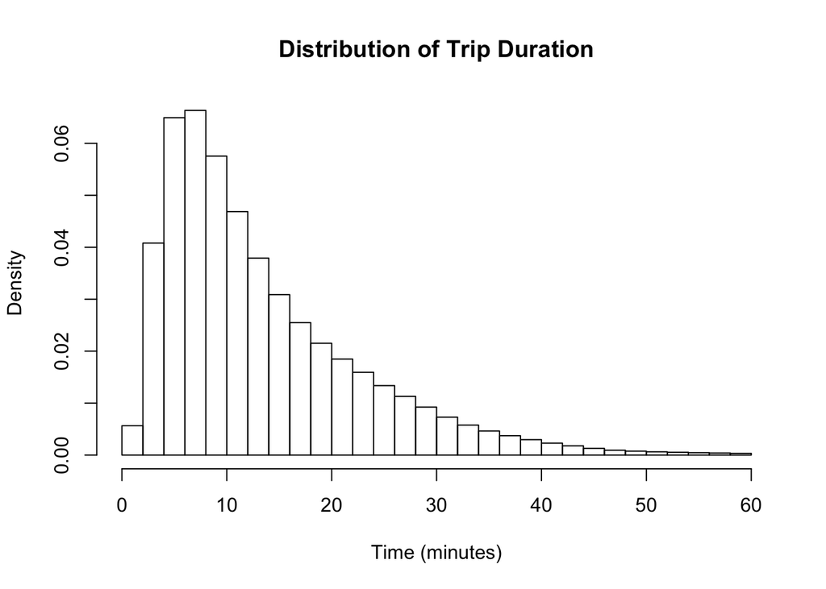

```r
#Excluding the extreme outliers of trip duration
bikest <- filter(bikes, tripduration < 3600)

#Converting seconds to minutes
bikest$tripduration <- bikest$tripduration/60

#Plotting the duration histogram
hist(bikest$tripduration, 30, main = "Distribution of Trip Duration", xlab = "Time (minutes)", probability = TRUE)
```

#### 1.4.2 Visualizing the distribution of age

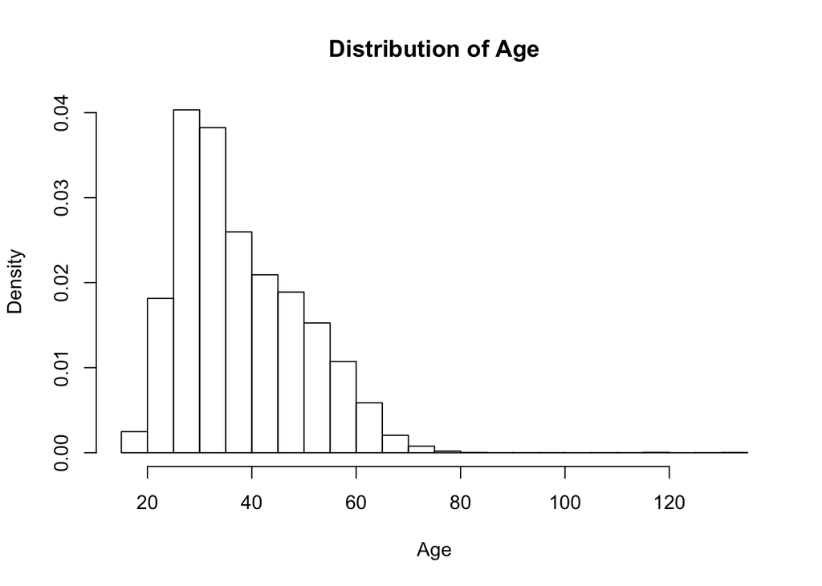

```r
#Plotting the age histogram
hist(bikes$age, main = "Distribution of Age", xlab = "Age", probability = TRUE)
```

To explore future relationships with age, such as the relationship between age and traveling speed (see Section 2.3), we create a subset from `bikes` that excludes 257631 observations that have no entry in the `age` column.

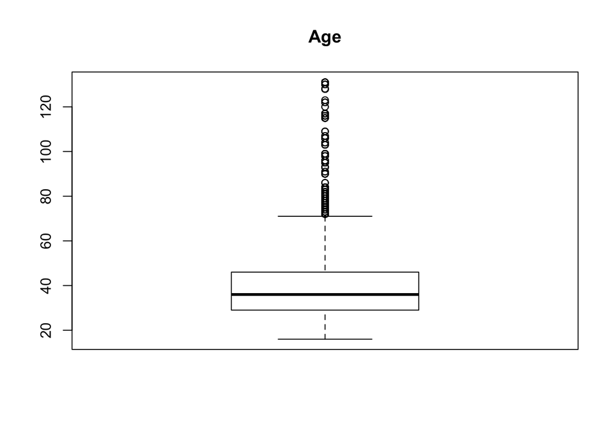

```r
#Creating a subset which excludes empty age entries
bikes_no.age.na <- subset(bikes, (is.na(bikes$age) == FALSE) )

#Plotting age boxplot
boxplot(bikes_no.age.na$age, main = "Age")
```

The boxplot shows that there are a significant number of outliers, which is not surprising considering the age/birth year problems we identified and briefly discussed in Section 1.2. We will further process the age data in two different ways:

1. 871 observations with an `age` greater than 90 will be deleted.
2. 3245 observations with an `age` between 75 and 90 will be grouped together as `age` 75. For conveniece, we do not name it “75+” so that the program knows to handle an integer.

```r
bikes_no.age.na <- subset(bikes_no.age.na, bikes_no.age.na$age < 90)
bikes_no.age.na$age <- ifelse(bikes_no.age.na$age > 74, 75, bikes_no.age.na$age)
```

All in all, we deleted 12.6% and manipulated another 0.16% of the original data in bikes.

#### 1.4.3 Visualizing travel distances

We first examine an overall distribution of all estimated trip distances.

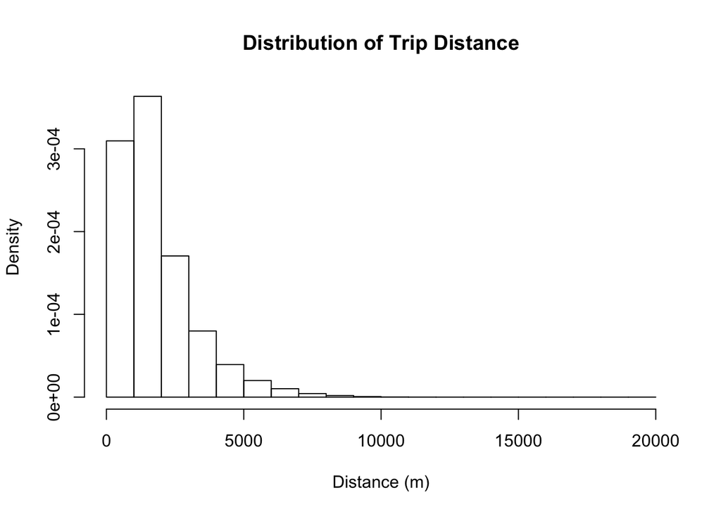

```r
hist(bikes$distance, main = "Distribution of Trip Distance", xlab = "Distance (m)", probability = TRUE)
```

To understand how the average trip distance may be changing over the course of the year, we examine average distance as a function of the month.

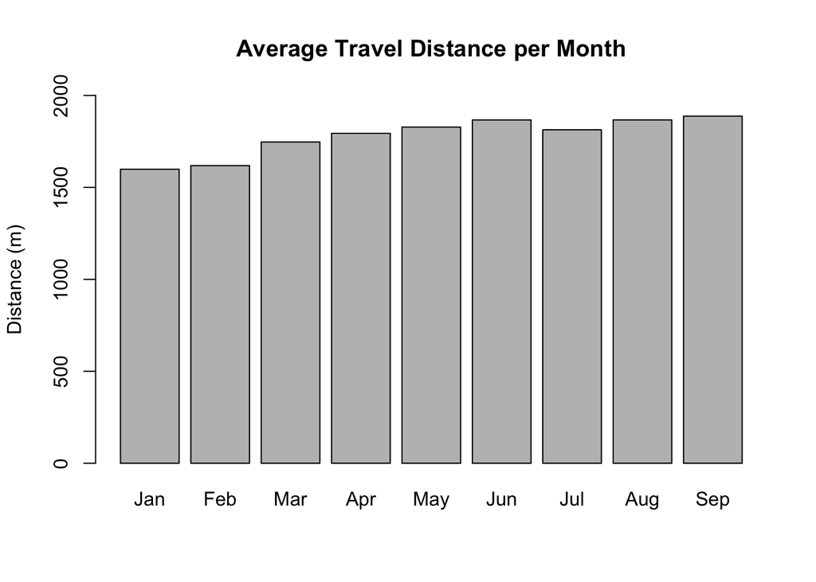

```r
barplot(tapply(X = bikes$distance, INDEX = bikes$month, FUN = mean, na.rm =T), names.arg = c("Jan", "Feb", "Mar", "Apr", "May", "Jun", "Jul", "Aug", "Sep"), ylim = c(0, 2000), main = "Average Travel Distance per Month", ylab = "Distance (m)")
```

Though average distance over the course of the year appears to be relatively stable, there is still a noticeable increase in the average trip distance for spring, summer, and fall months over winter months. The average distance appears to be around 1600m in Jan and Feb, while the average distance jumps to around 1800m for Jun through Sep.

## 2.0 Identifying patterns in the data

**Explain/illustrate these patterns using appropriate visualization.**

### 2.1 Examining traffic patterns

To discover traffic patterns, we evaluate the number of rides per hour on both daily and monthly scales.

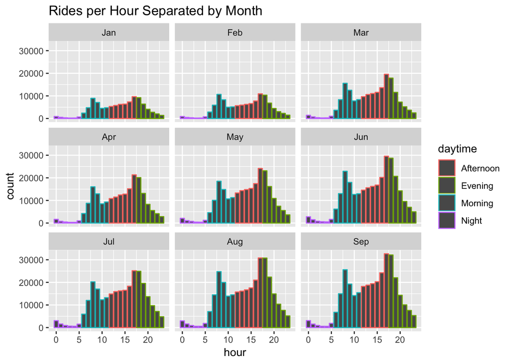

```r
plot_uh <- ggplot(data = bikes, aes(x=hour, colour = daytime))
plot_uh + geom_bar() + facet_wrap( ~month) + ggtitle("Rides per Hour Separated by Month")
```

This plot shows that overall CitiBike traffic for 2016 has been increasing steadily throughout the year, with Jan and Feb being the lowest traffic months and Aug and Sep being the highest traffic months thus far this year.

For every month, the largest amount of traffic (highest rides per hour) occur from 5-6pm, which makes sense as this timeframe is consistent with the “rush hour” traffic associated with the end of the workday. For every month, the second highest peak throughout the day occurs at 8am.

Expectedly, the overall traffic pattern (peaks at 8am and 5-6pm, steady afternoon traffic, and a steep lull in nighttime traffic) is pretty consistent from month to month.

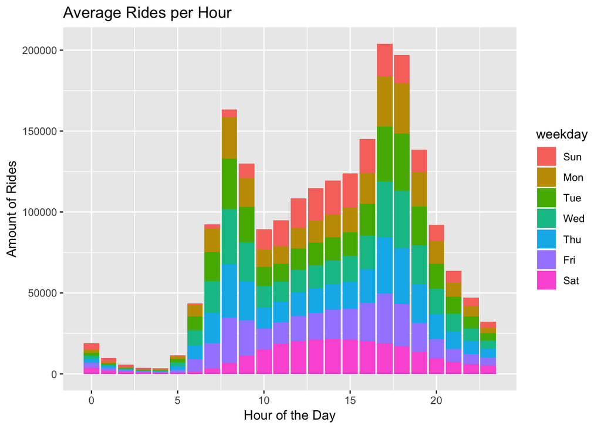

```r
#Graphing average rides per hour coloured with weekdays
plot_6 <- ggplot(bikes, aes(x=hour, fill = weekday, label = hour))
plot_6+geom_bar()+ggtitle("Average Rides per Hour")+labs(x= "Hour of the Day", y= "Amount of Rides")
```

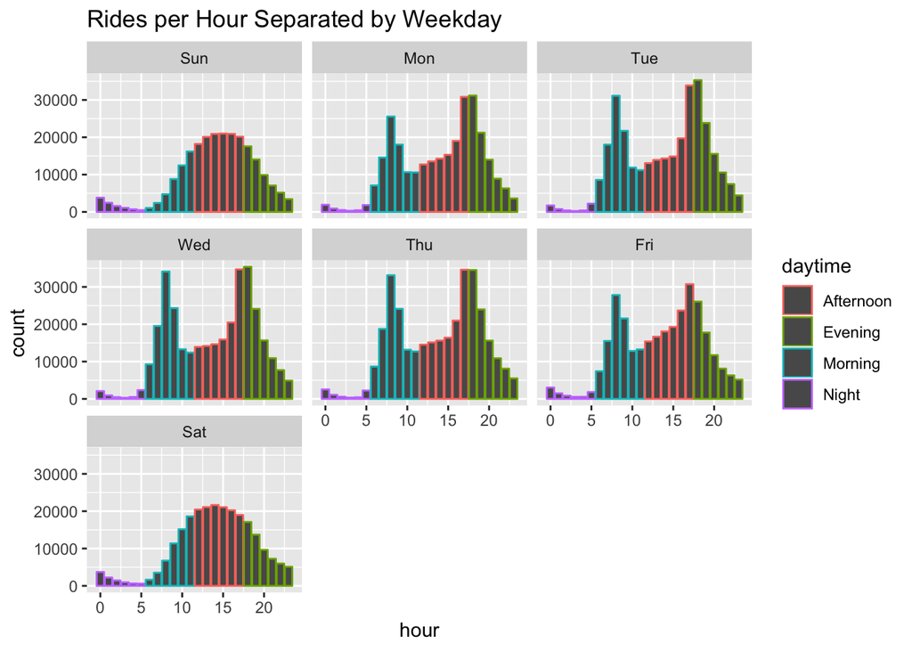

```r
#Graphing rides per hour as a function of weekday
plot_uh2 <- ggplot(data = bikes, aes(x=hour, colour = daytime))
plot_uh2 + geom_bar()+facet_wrap( ~weekday)+ggtitle("Rides per Hour Separated by Weekday")
```

The above plots further reveal that the overall traffic pattern discussed above arises as the “average” due to the “weekday” data dominating over the “weekend” data. As seen from above, the two-peak traffic pattern is very pronounced for all weekdays. On weekends, a very different traffic pattern emerges. Instead of the two peaks associated with commuting to/from work or school, the traffic pattern on Saturdays and Sundays exhibits a parabolic pattern which resembles a normal distribution. On these days, peak traffic occurs from 2-3pm and the traffic asymmetrically decreases at a smaller slope into the evening hours, showing there is more evening traffic than morning traffic. It is also noteworthy that the weekend days show noticeably more nighttime traffic (especially 12-2am) than weekdays.

Further comparing weekends to weekdays while also taking date/month into account, we plot the number of rides per day as a function of both variables.

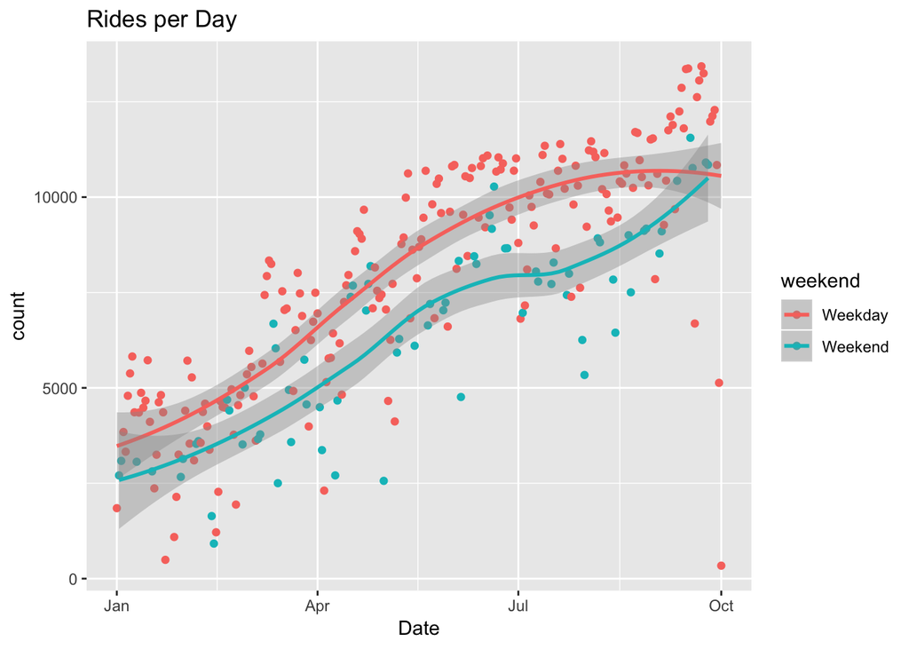

```r
bydate <- group_by(bikes, date)
date_summary1 <- summarise(bydate, count = n(), distance = mean(distance, na.rm =  T), weekend = weekend[1])
plot_3 <- ggplot(date_summary1, aes(x=date, y= count , colour = weekend))
plot_3+geom_point()+geom_smooth()+ggtitle("Rides per Day")+labs(x = "Date")
```

### 2.2 Examining frequent route patterns

To identify which routes are being most frequently traveled, we first combine both the starting and the ending destination into a new variable.

```r
bikes$start_end <- paste(bikes$start.station.name, bikes$end.station.name, sep = "-->")
```

We can then determine which of these travel patterns are recurring the most frequently by plotting this new variable we created.

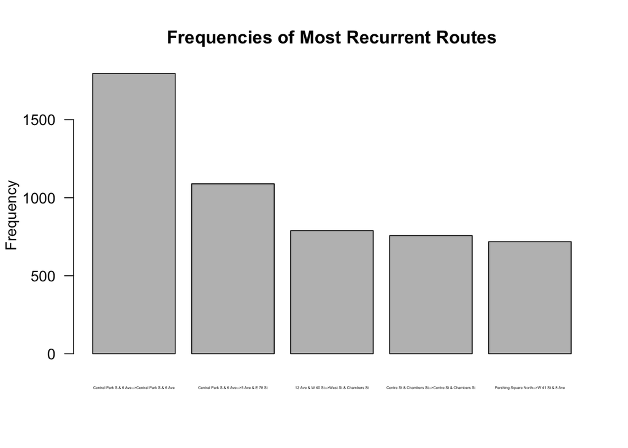

```r
barplot(sort(table(bikes$start_end),decreasing=TRUE)[1:5], main = "Frequencies of Most Recurrent Routes", ylab = "Frequency", las = 1, cex.names = 0.25)
```

From this plot, we can see that the most frequent route pattern, by far, is the route which both starts and ends at the station at Central Park S & 6 Ave. This proves that users riding around/through Central Park is a highly reliable and recurrent pattern. This route occurs more than 50% more frequently than the next most traveled route.

### 2.3 Assessing potential speed patterns

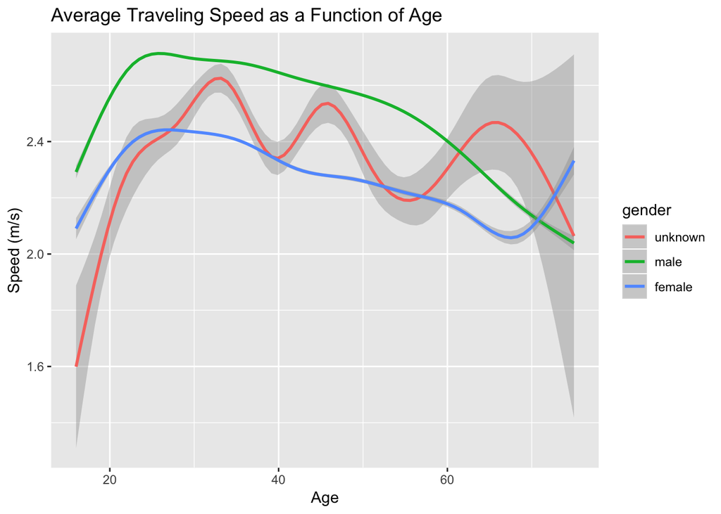

```r
plot_as <- ggplot(bikes_no.age.na, aes(x = age, y = speed, colour = gender))
plot_as + geom_smooth()+ggtitle("Average Traveling Speed as a Function of Age")+labs(x = "Age", y="Speed (m/s)")
```

As we expected, there does appear to be a pattern when looking at speed through the lenses of age and gender. On average, males bicycle at a faster speed than females. Interestingly, this pattern reverses and female riders become faster than males at ages greater than 70. As we expected, average speed does gradually decline as age increases, but we did not expect that speed also declines for young riders below (approximately) 25 years old. Both male and females’ average cycling speed peaks at age 25. In general, a peak average speed of about 2.7 m/s occurs for males aged 25-30.

### 2.4 Assessing potential distance patterns

This section examines whether there are any discernable patterns between ride distance, time of year, and weekday vs. weekend.

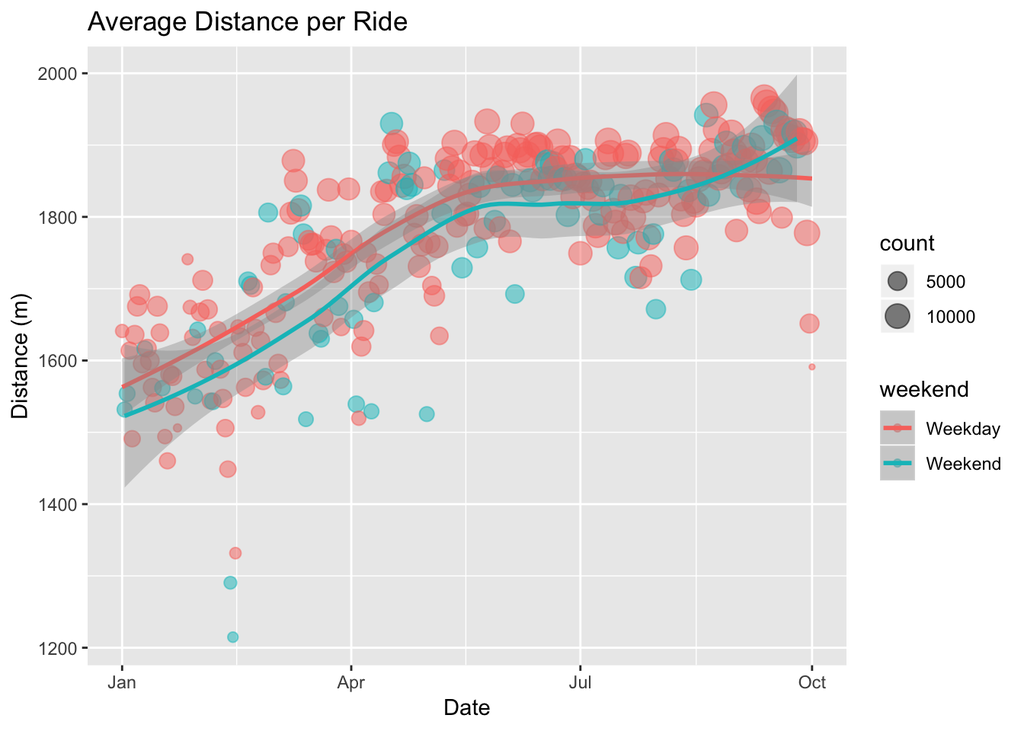

```r
plot_1 <- ggplot(date_summary1, aes(x=date, y= distance, colour = weekend))
plot_1 +geom_point(aes(size = count), alpha = 1/2)+geom_smooth()+ggtitle("Average Distance per Ride")+labs(x = "Date", y="Distance (m)")
```

### 2.5 Assessing potential duration patterns

This section examines whether there are any discernable patterns between ride duration, time of year, and weekday vs. weekend.

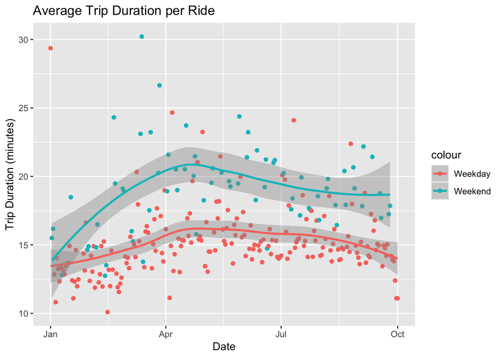

```r
date_summary4 <- summarise(bydate, tripduration = mean(tripduration, na.rm = T)/60, count = mean(distance, na.rm =T), colour = weekend[1])
plot_4 <- ggplot(date_summary4, aes(x=date, y=tripduration, colour = colour))
plot_4 + geom_point() + geom_smooth() + ggtitle("Average Trip Duration per Ride") + labs(x = "Date", y = "Trip Duration (minutes)")
```

We can identify the pattern that weekend trip durations are, on average, longer than weekday trip durations. Further, the shaded regions around each line show that there’s more variation in the average weekend trip duration; the average weekday trip duration is much more consistent/stable, which makes sense as users are more likely to be on a fixed path instead of meandering/exploring.

Unlike the increasing patterns of both traffic frequency and trip distance, as seen in Sections 2.1 and 2.4, respectively, average trip duration does not appear to significantly or continuously increase over the course of the year. Like both other variables, there is still a noticeable increase relative to the winter months (Jan and Feb), but then instead of continuing to increase, the trip duration peaks in the late spring/early summer (around May) and then decreases in the transition from summer to fall months.

For weekend trips, this peak average is around 21-22 minutes per trip; for weekday trips, this peak average significantly drops to 16-17 minutes.

## 3.0 Examining asymmetric traffic

We compare the amount of incoming and leaving bikes per station only for the month September to decrease computing time. The same code would run for the entire period of nine months, but would need way more time without relevant changes to our findings. First we prepare the dataset for September by running a couple of the same commands as in the beginning of the document.

```r
sep <- bikes09

sep$starttime <- as.POSIXct(sep$starttime,format = c("%m/ %d/ %Y %H: %M"))
sep$stoptime <- as.POSIXct(sep$stoptime,format = c("%m/ %d/ %Y %H: %M"))
#Creating a seperate "date" column for yearly overview
sep$date <- as.Date(sep$starttime)

#Creating columns that indicate weekday or weekend
sep$weekday <- wday(sep$starttime)
sep$weekday <- as.factor(sep$weekday)
levels(sep$weekday) <- c("Sun", "Mon", "Tue", "Wed", "Thu", "Fri", "Sat")
sep$weekend <- ifelse(sep$weekday == "Sat" | sep$weekday == "Sun", "Weekend", "Weekday")
sep$weekend <- as.factor(sep$weekend)
stations <- filter(sep, weekend == "Weekday")
```

```r
#Counting the number of rides starting or ending at each station and merging these tables
bikes.departures <- table(stations$start.station.name)
bikes.arrivals <- table(stations$end.station.name)
departure.arrivals <- merge(bikes.departures, bikes.arrivals, by="Var1")

#Since we lost longitude and latitude in the step above, we now create a table with these values for each station
station.list <- distinct(select (bikes, start.station.name, start.station.latitude, start.station.longitude))
station.list <- rename(station.list, "Var1" = start.station.name)

#merging geodata and number of rides for each station
departure.arrivals <- merge(departure.arrivals, station.list, by = "Var1")

#renaming for convenience
departure.arrivals <- rename(departure.arrivals, "number.dep" = Freq.x, "number.arr" = Freq.y, "start.station.name" = Var1, "latitude" = start.station.latitude, "longitude" = start.station.longitude)

#column "sum" is overall number of arrivals minus overall number of departues for September
#divided by number of weekdays for this period
departure.arrivals$sum <- (departure.arrivals$number.arr - departure.arrivals$number.dep)/22

#Creating new dataset only containing top and bottom 20 stations (loss/gain per day)
map4 <- departure.arrivals[order(departure.arrivals$sum, decreasing = T),]
map4 <- map4[1:20,]
map5 <- departure.arrivals[order(departure.arrivals$sum, decreasing = F),]
map5 <- map5[1:20,]
map6 <- rbind(map5, map4)
map6 <- map6[order(map6$sum, decreasing = T),]

leaflet(data = map6) %>% addTiles() %>% addCircleMarkers (radius = ~ abs(sum)/4, color = ~ ifelse(sum > 0, "green", "red"), stroke = FALSE, fillOpacity = 0.5, ~ longitude, ~ latitude, label = ~ paste("Station: ", start.station.name, "," , ifelse(sum > 0, "Average gain per day: ", "Average loss per day: "), round(abs(sum), digits = 2)))
```

[interactive chart not shown]

There is no pattern of stations losing or gaining bikes for weekdays as red and green spots are randomly distributed over the map. It is important to notice than some stations experience a significant loss of bikes that should be covered with either bigger capacity or supply from other stations.

Stations which lose most bikes per day on weekdays:

1. Penn Station Valet with an average loss of : 124.8
2. W 42 St & Dyer Ave with an average loss of : 98.1
3. E 47 St & Park Ave with an average loss of : 50.9

Stations which gain most bikes per day on weekdays:

1. E 10 St & Avenue A with an average gain of : 77.4
2. West St & Chambers St with an average gain of : 44
3. W 33 St & 7 Ave with an average gain of : 41.9

```r
stations <- filter(bikes, weekend == "Weekend")

#Counting the number of rides starting or ending at each station and merging these tables
bikes.departures <- table(stations$start.station.name)
bikes.arrivals <- table(stations$end.station.name)
departure.arrivals <- merge(bikes.departures, bikes.arrivals, by="Var1")

#Since we lost longitude and latitude in the step above, we now create a table with these values for each station
station.list <- distinct(select (bikes, start.station.name, start.station.latitude, start.station.longitude))
station.list <- rename(station.list, "Var1" = start.station.name)

#merging geodata and number of rides for each station
departure.arrivals <- merge(departure.arrivals, station.list, by = "Var1")

#renaming for convenience
departure.arrivals <- rename(departure.arrivals, "number.dep" = Freq.x, "number.arr" = Freq.y, "start.station.name" = Var1, "latitude" = start.station.latitude, "longitude" = start.station.longitude)

#column "sum" is overall number of arrivals minus overall number of departues for September
#divided by number of weekend days for this period
departure.arrivals$sum <- (departure.arrivals$number.arr - departure.arrivals$number.dep)/8


#Creating new dataset only containing top and bottom 20 stations (loss/gain per day)
map <- departure.arrivals[order(departure.arrivals$sum, decreasing = T),]
map <- map[1:20,]
map1 <- departure.arrivals[order(departure.arrivals$sum, decreasing = F),]
map1 <- map1[1:20,]
map3 <- rbind(map, map1)
map3 <- map3[order(map3$sum, decreasing = T),]

leaflet(data = map3) %>% addTiles() %>% addCircleMarkers (radius = ~ abs(sum)/2, color = ~ ifelse(sum > 0, "green", "red"), stroke = FALSE, fillOpacity = 0.5, ~ longitude, ~ latitude, label = ~ paste("Station: ", start.station.name, "," , ifelse(sum > 0, "Avergae gain per day: ", "Average loss per day: "), round(abs(sum), digits = 2)))
```

[interactive chart not shown]

There seems to be a pattern of rides beginning in the upper part of Manhattan and ending in the lower part when people use citiBike on weekends. Furthermore the stations with the biggest loss and gain have changed from typical commuting locations (train stations, etc. ) to touristic hotspots like Central Park or lower Manhattan.

Stations which lose most bikes per day on weekends:

1. Grand Army Plaza & Central Park S with an average loss of : 69.9
2. Central Park S & 6 Ave with an average loss of : 64.4
3. Central Park West & W 68 St with an average loss of : 36.1

Stations which gain most bikes per day on weekends:

1. W 18 St & 6 Ave with an average gain of : 38.9
2. E 16 St & 5 Ave with an average gain of : 32.6
3. W 20 St & 11 Ave with an average gain of : 30.5

## 4.0 Examining the impact of weather

**Client wants to know the impact of weather (temperature, rain, snow, wind) on the CitiBike system.**

### 4.1 Importing, incorporating, and cleaning the weather data

```r
#Reading the weather data
weather <- read.csv("weather_data.csv")

#Merging the weather data with the bike ride data
date_summary6 <- summarise(bydate, count = n(), distance = mean(distance, na.rm =  T), tripduration = mean(tripduration, na.rm = T))
weather$date <- as.Date(as.character(weather$DATE), "%Y%m%d")
bike_weather <- merge(date_summary6, weather, by.x= "date", by.y = "date")
bike_weather$avgtemp <- (bike_weather$TMAX+bike_weather$TMIN)/2
bike_weather$avgtempsq <- bike_weather$avgtemp^2
bike_weather$TMINsq <- bike_weather$TMIN^2
bike_weather$TMAXsq <- bike_weather$TMAX^2

#Cleaning the merged data
bike_weather$weekday <- wday(bike_weather$date)
bike_weather$weekday <- as.factor(bike_weather$weekday)
levels(bike_weather$weekday) <- c("Mon", "Tue", "Wed", "Thu", "Fri", "Sat", "Sun")
bike_weather$weekend <- ifelse(bike_weather$weekday == "Sat" | bike_weather$weekday == "Sun", "Weekend", "Weekday")
bike_weather$weekend <- as.factor(bike_weather$weekend)
```

### 4.2 Visualizing the impact of weather

#### 4.2.1 Visualizing the impact of temperature

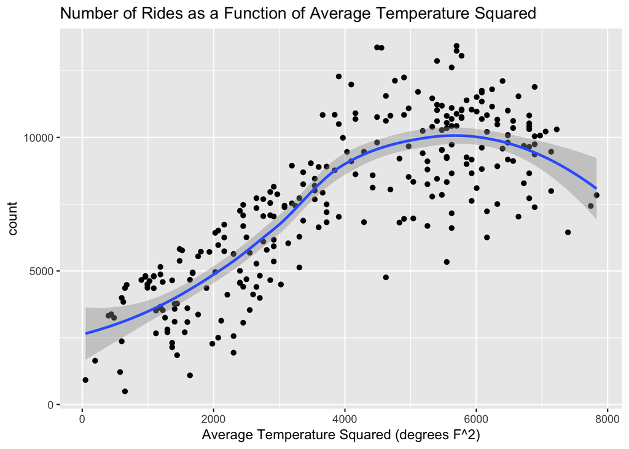

```r
temp_rides <- ggplot(data = bike_weather, aes(x = avgtempsq, y = count))
temp_rides + geom_point() + geom_smooth() + ggtitle("Number of Rides as a Function of Average Temperature Squared") + xlab("Average Temperature Squared (degrees F^2)")
```

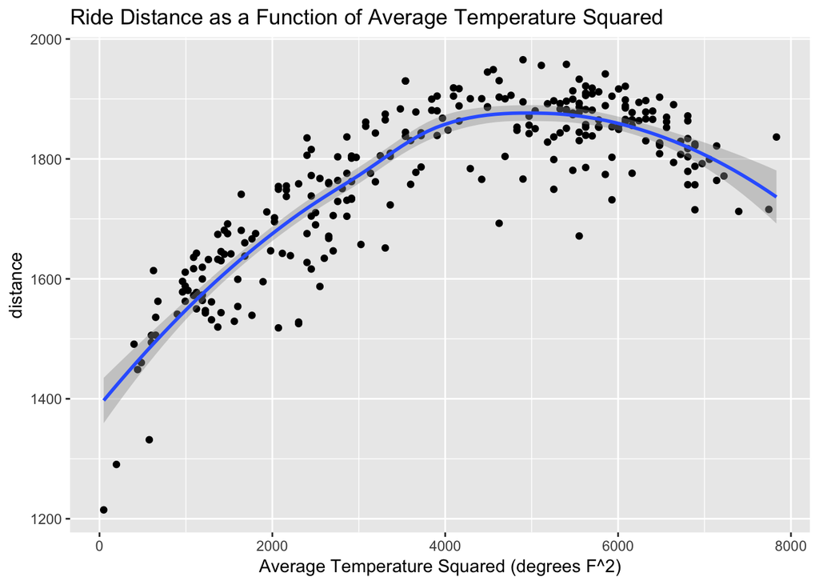

```r
temp_dist <- ggplot(data = bike_weather, aes(x = avgtempsq, y = distance))
temp_dist + geom_point() + geom_smooth() + ggtitle("Ride Distance as a Function of Average Temperature Squared") + xlab("Average Temperature Squared (degrees F^2)")
```

These two graphs show the relationship between temperature and the number of rides and distance riders travelled. The first graph shows temperature squared in relation to number of rides per day and the second displays the temperature squared in relation to the distance riders travel. As we can see, the most and longest rides tend to be taken at moderate temperatures and both variables drop at much lower and much higher temperatures.

#### 4.2.1 Visualizing the impact of snow

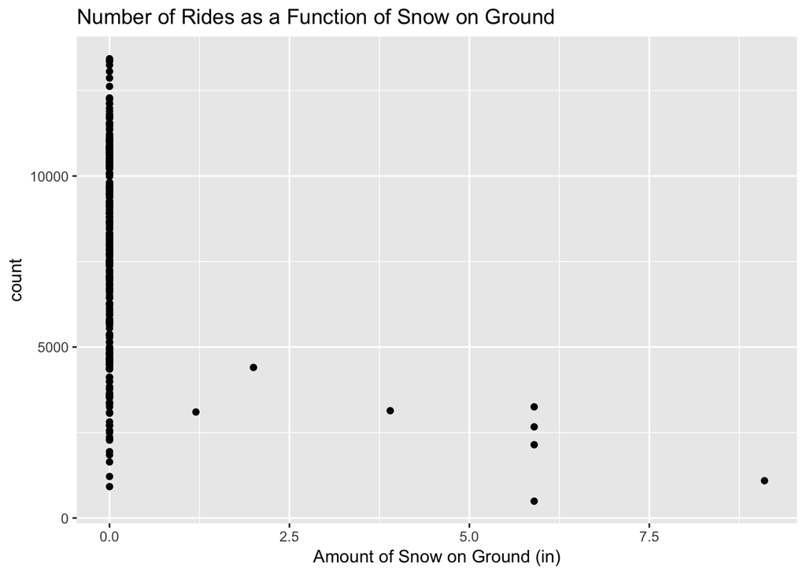

```r
gsnow_rides <- ggplot(data = bike_weather, aes(x = SNWD, y = count))
gsnow_rides + geom_point() + ggtitle("Number of Rides as a Function of Snow on Ground") + xlab("Amount of Snow on Ground (in)")
```

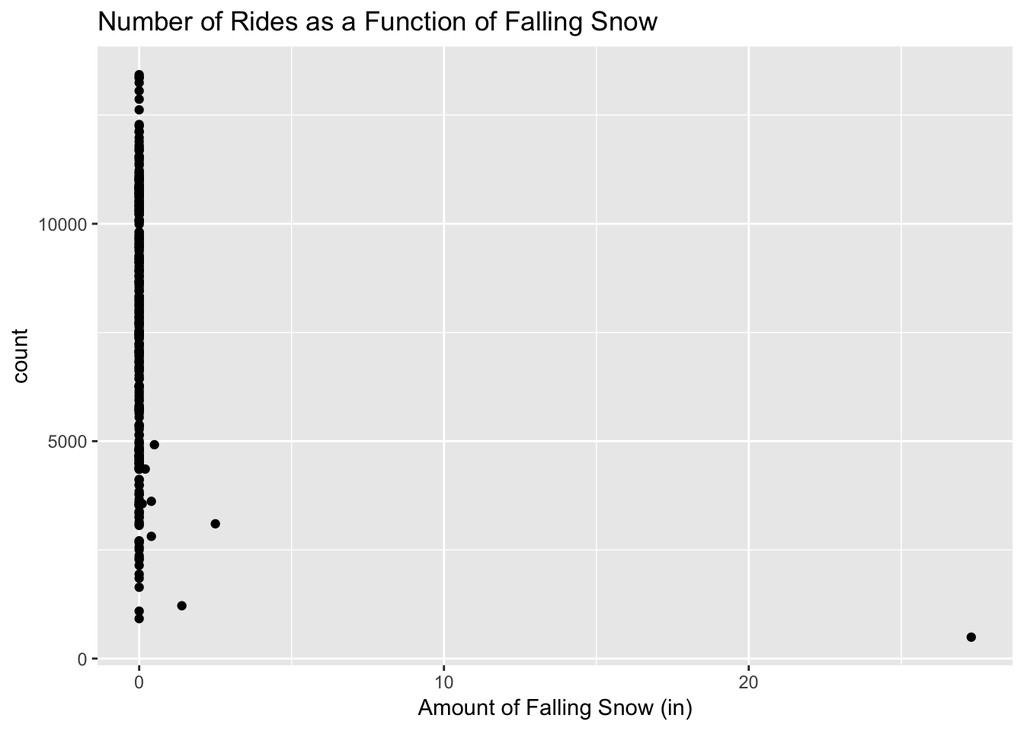

```r
snowfall_rides <- ggplot(data = bike_weather, aes(x = SNOW, y = count))
snowfall_rides + geom_point() + ggtitle("Number of Rides as a Function of Falling Snow") + xlab("Amount of Falling Snow (in)")
```

Together, these plots show that ride traffic significantly decreases with the presence of both falling snow and existing snow on the ground. Note that there are only very few days with snow which makes this anlysis less significant than the connection to temperature.

### 4.3 Modeling the expected traffic given day and weather conditions

#### 4.3.1 Constructing a linear regression model

We constructed several linear regression models that aimed at predicting the “count,” or the number of rides per day, as a function of several predictor variables. We experimented with all of the following predictor variables: day of the week, weekday vs. weekend, average temperature, precipitation, snowfall, existing snow, and wind. The following code represents the model which best described the data.

```r
bike_model <- lm(count ~ weekday + avgtemp + PRCP + SNWD + SNOW + DATE, data = bike_weather)
summary(bike_model)
```

```
##
## Call:
## lm(formula = count ~ weekday + avgtemp + PRCP + SNWD + SNOW +
##     DATE, data = bike_weather)
##
## Residuals:
##     Min      1Q  Median      3Q     Max
## -3864.8  -699.4    32.8   724.0  4165.9
##
## Coefficients:
##               Estimate Std. Error t value Pr(>|t|)
## (Intercept) -1.001e+08  1.028e+07  -9.737  < 2e-16 ***
## weekdayTue   1.064e+03  2.583e+02   4.119 5.12e-05 ***
## weekdayWed   1.767e+03  2.583e+02   6.840 5.68e-11 ***
## weekdayThu   2.093e+03  2.570e+02   8.144 1.63e-14 ***
## weekdayFri   1.962e+03  2.576e+02   7.616 4.92e-13 ***
## weekdaySat   1.630e+03  2.549e+02   6.396 7.42e-10 ***
## weekdaySun   2.992e+02  2.583e+02   1.158    0.248
## avgtemp      7.394e+01  7.338e+00  10.076  < 2e-16 ***
## PRCP        -2.719e+03  2.735e+02  -9.940  < 2e-16 ***
## SNWD        -3.285e+02  8.115e+01  -4.048 6.82e-05 ***
## SNOW         2.263e+02  5.081e+01   4.454 1.25e-05 ***
## DATE         4.965e+00  5.100e-01   9.737  < 2e-16 ***
## ---
## Signif. codes:  0 '***' 0.001 '**' 0.01 '*' 0.05 '.' 0.1 ' ' 1
##
## Residual standard error: 1125 on 259 degrees of freedom
## Multiple R-squared:  0.8626, Adjusted R-squared:  0.8567
## F-statistic: 147.8 on 11 and 259 DF,  p-value: < 2.2e-16
```

This model indicates that date, day of the week (excluding Sunday), average temperature, precipitation, snowfall, and existing snow on the ground are all variables which highly significantly impact the number of rides per day.

In regards to the weather-related predictor variables, the important of these is precipitation. The coefficient of precipitation has the largest magnitude; therefore, it has the largest negative impact on ride count among any of the other weather-related variables in the model.

The adjusted R squared value indicates that nearly 86% of the variation in ride count can be explained by the variation in date, day of the week (excluding Sunday), average temperature, precipitation, snowfall, and existing snow on the ground.

#### 4.3.2 Using the linear regression model

We ran the above model (Section 4.3.1) to estimate what the number of CitiBike rides would be if the conditions were as follows:

Day = Wednesday Date = October 31, 2018 (today’s date) Average temp = 51 degrees F Precipitation = 0.5 in Snowfall = 0 in Existing snow on ground = 0 in

```r
testvalue <- data.frame(weekday = "Wed", avgtemp = 51, PRCP = 0.5, SNWD = 0, SNOW = 0, DATE = 20181031)
p <- predict(bike_model, newdata = testvalue, interval = "confidence")
p
```

```
##        fit      lwr      upr
## 1 108188.2 87474.49 128901.8
```

#### 4.3.3 Constructing a classification model

We use a KNN algorithm, which is a classification algorithm, in order to predict whether any given day will be classified as a high traffic day (count is greater than or equal to 7,500) or a low traffic day (count is less than 7,500). The cut-off determination was selected as 7,500 based on that value being the median of the count data.

Before running the model, we first complete all of the following preparations, including normalizing the variables and differentiating between training and testing data.

```r
#Creating normalization function
normalize <- function(x){
  return ((x - min(x)) / (max(x) - min(x)))
}

#Preparing new dataset
bike_weather_new <- bike_weather
bike_weather_new$AWND <- NULL
bike_weather_new$STATION_NAME <- NULL
bike_weather_new$DATE <- NULL
bike_weather_new <- bike_weather_new[-1]
bike_weather_new <- bike_weather_new[-2]
bike_weather_new <- bike_weather_new[-2]
bike_weather_new <- bike_weather_new[-2]
bike_weather_new$count <- ifelse(bike_weather_new$count<=7500, 0, 1)
bike_weather_new$weekday <- as.integer(bike_weather_new$weekday)
bike_weather_new$weekend <- as.integer(bike_weather_new$weekend)

#Normalizing the variables
bike_weather_n <- as.data.frame(lapply(bike_weather_new[2:9], normalize))

#Separating train and test data
train_sample <- sample(seq_len(nrow(bike_weather_new)), size = 189)
bike_weather_n_train <- bike_weather_n[train_sample, ]
bike_weather_n_test <- bike_weather_n[-train_sample, ]
bike_weather_n_train_labels <- bike_weather_new[train_sample,1]
bike_weather_n_test_labels <- bike_weather_new[-train_sample,1]
```

We then ran the KNN model function:

```r
# k = sqrt(train size) = sqrt(189) = 13
bike_weather_n_pred <- knn(train = bike_weather_n_train, test = bike_weather_n_test, cl = bike_weather_n_train_labels, k=13)
```

#### 4.3.4 Testing the classification model

The following commands test the accuracy of how well our classification model (Section 4.3.3) correctly classifies a given day into high or low traffic.

```r
c <- CrossTable(x = bike_weather_n_test_labels, y = bike_weather_n_pred, prop.chisq = FALSE)
```

```
##
##
##    Cell Contents
## |-------------------------|
## |                       N |
## |           N / Row Total |
## |           N / Col Total |
## |         N / Table Total |
## |-------------------------|
##
##
## Total Observations in Table:  82
##
##
##                            | bike_weather_n_pred
## bike_weather_n_test_labels |         0 |         1 | Row Total |
## ---------------------------|-----------|-----------|-----------|
##                          0 |        27 |         7 |        34 |
##                            |     0.794 |     0.206 |     0.415 |
##                            |     0.871 |     0.137 |           |
##                            |     0.329 |     0.085 |           |
## ---------------------------|-----------|-----------|-----------|
##                          1 |         4 |        44 |        48 |
##                            |     0.083 |     0.917 |     0.585 |
##                            |     0.129 |     0.863 |           |
##                            |     0.049 |     0.537 |           |
## ---------------------------|-----------|-----------|-----------|
##               Column Total |        31 |        51 |        82 |
##                            |     0.378 |     0.622 |           |
## ---------------------------|-----------|-----------|-----------|
##
##
```

We found that our model successfully predicts high vs. low traffic with an accuracy of 86.59% and an error rate of 13.41% within one of the samples we generated.